# **DATA MINING - Projet Botanic**

## **3. Equilibrage des jeux de données**

```python
# Equilibrage des données
print(df_botanic['Y_attrition'].value_counts())
print(df_botanic['Y_attrition'].value_counts()/len(df_botanic))
```

```
0_Non Attritionniste    294251
Attritionniste          294251
Name: Y_attrition, dtype: int64
0_Non Attritionniste    0.5
Attritionniste          0.5
Name: Y_attrition, dtype: float64
```

- **Non Attritionniste : 0.5**
- **Attritionniste : 0.5**

## **4. Binarisation des variables**

```python
# Binarisation des variables
df_dummies = df_botanic.copy(deep=True)
df_dummies_x = df_botanic.copy(deep=True)
columns_x_list = df_dummies.columns
for var in columns_x_list:
    df_dummies_x=df_dummies_x.drop(var,axis=1)
for var in columns_x_list:
        cat_list = pd.get_dummies(df_dummies[var],prefix=var,drop_first=True)
        data1=df_dummies_x.join(cat_list)
        df_dummies_x = data1
df_dummies_x.head()
```

|  | Y_attrition_Attritionniste | CIVILITE_MONSIEUR | TrancheAge_1_Sans age | TrancheAge_2_Moins de 40 ans | TrancheAge_3_Entre 40 et 60 | readhesion_readherent | TrancheDureeAdhesion_1_Non adherent | TrancheDureeAdhesion_2_moins de 18 mois | TrancheDureeAdhesion_3_entre 18 et 46 mois | domiciliation_Alsace-Est | ... | MARGESORTIE_CAT_Q2_entre_20_37 | MARGESORTIE_CAT_Q3_entre_37_61 | U1_CAT_Q1_moins de 4 | U1_CAT_Q2_Entre 4 et 9 | U1_CAT_Q3_Entre 10 et 18 | U2_CAT_Q1_moins de 2 | U2_CAT_Q2_Entre 2 et 3 | U2_CAT_Q3_Entre 4 et 7 | U3_CAT_Q1_moins de 5 | U4_CAT_Q1_moins de 3 |
| --- | --- | --- | --- | --- | --- | --- | --- | --- | --- | --- | --- | --- | --- | --- | --- | --- | --- | --- | --- | --- | --- |
| 0 | 0 | 1 | 0 | 1 | 0 | 1 | 0 | 0 | 0 | 0 | ... | 0 | 0 | 1 | 0 | 0 | 1 | 0 | 0 | 1 | 1 |
| 1 | 0 | 0 | 0 | 1 | 0 | 1 | 0 | 0 | 0 | 0 | ... | 0 | 0 | 1 | 0 | 0 | 1 | 0 | 0 | 1 | 1 |
| 2 | 0 | 1 | 1 | 0 | 0 | 0 | 0 | 0 | 1 | 1 | ... | 0 | 0 | 1 | 0 | 0 | 1 | 0 | 0 | 1 | 1 |
| 3 | 1 | 1 | 1 | 0 | 0 | 1 | 0 | 0 | 1 | 0 | ... | 0 | 0 | 1 | 0 | 0 | 1 | 0 | 0 | 1 | 1 |
| 4 | 1 | 0 | 0 | 0 | 1 | 1 | 0 | 0 | 1 | 0 | ... | 0 | 0 | 1 | 0 | 0 | 1 | 0 | 0 | 1 | 1 |

5 rows × 44 columns

## **5. Séparation des données en jeu d'apprentissage et jeu de test**

**Le jeu de données a été separé en jeu d'apprentissage (70%) et en jeu de test (30%)**

```python
df_dummies_x.columns
```

```
Index(['Y_attrition_Attritionniste', 'CIVILITE_MONSIEUR',
       'TrancheAge_1_Sans age', 'TrancheAge_2_Moins de 40 ans',
       'TrancheAge_3_Entre 40 et 60', 'readhesion_readherent',
       'TrancheDureeAdhesion_1_Non adherent',
       'TrancheDureeAdhesion_2_moins de 18 mois',
       'TrancheDureeAdhesion_3_entre 18 et 46 mois',
       'domiciliation_Alsace-Est', 'domiciliation_Centre-Paris',
       'domiciliation_Littoral', 'r_score_2', 'r_score_3', 'r_score_4',
       'f_score_1', 'f_score_2', 'f_score_3', 'm_score_1', 'm_score_2',
       'm_score_3', 'Region_achat_Alsace-Est', 'Region_achat_Centre-Paris',
       'Region_achat_Littoral', 'TIC_TOTALTTC_CAT_Q1_inferieur_59',
       'TIC_TOTALTTC_CAT_Q2_entre_59_108', 'TIC_TOTALTTC_CAT_Q3_entre_108_184',
       'MONTANTREMISE_CAT_Q1_inferieur_0.5',
       'MONTANTREMISE_CAT_Q2_entre_0.5_6', 'MONTANTREMISE_CAT_Q3_entre_6_12',
       'TOTAL_CAT_Q1_inferieur_41', 'TOTAL_CAT_Q2_entre_41_77',
       'TOTAL_CAT_Q3_entre_77_129', 'MARGESORTIE_CAT_Q1_inferieur_20',
       'MARGESORTIE_CAT_Q2_entre_20_37', 'MARGESORTIE_CAT_Q3_entre_37_61',
       'U1_CAT_Q1_moins de 4', 'U1_CAT_Q2_Entre 4 et 9',
       'U1_CAT_Q3_Entre 10 et 18', 'U2_CAT_Q1_moins de 2',
       'U2_CAT_Q2_Entre 2 et 3', 'U2_CAT_Q3_Entre 4 et 7',
       'U3_CAT_Q1_moins de 5', 'U4_CAT_Q1_moins de 3'],
      dtype='object')
```

```python
#création du jeu d'apprentissage et de test
colums_y = 'Y_attrition_Attritionniste'
X = df_dummies_x.drop(colums_y, axis=1)
Y = df_dummies_x[colums_y]
X_train, X_test, Y_train, Y_test = train_test_split(X,Y, test_size = 0.3, random_state = 0)
```

## **6. Entrainement du modèle avec la méthode backward**

**Méthode backward - itération N° 1**

|  | coef | Odds ratio | Interval de conf. min | Interval de conf. max | P-value |
| --- | --- | --- | --- | --- | --- |
| CIVILITE_MONSIEUR | 0.001437 | 1.001438 | -0.001176 | 0.004050 | 0.2810 |
| TrancheAge_1_Sans age | -0.029168 | 0.971253 | -0.032835 | -0.025501 | 0.0000 |
| TrancheAge_2_Moins de 40 ans | 0.001001 | 1.001002 | -0.003345 | 0.005348 | 0.6516 |
| TrancheAge_3_Entre 40 et 60 | -0.036528 | 0.964131 | -0.040471 | -0.032585 | 0.0000 |
| readhesion_readherent | 0.322487 | 1.380557 | 0.319296 | 0.325678 | 0.0000 |
| TrancheDureeAdhesion_1_Non adherent | 0.263093 | 1.300948 | 0.258146 | 0.268041 | 0.0000 |
| TrancheDureeAdhesion_2_moins de 18 mois | 0.276098 | 1.317977 | 0.272292 | 0.279904 | 0.0000 |
| TrancheDureeAdhesion_3_entre 18 et 46 mois | -0.000209 | 0.999791 | -0.003829 | 0.003412 | 0.9101 |
| domiciliation_Alsace-Est | -0.010817 | 0.989241 | -0.031981 | 0.010347 | 0.3165 |
| domiciliation_Centre-Paris | -0.024861 | 0.975446 | -0.040957 | -0.008764 | 0.0025 |
| domiciliation_Littoral | -0.012639 | 0.987441 | -0.029129 | 0.003851 | 0.1330 |
| r_score_2 | 0.026698 | 1.027058 | 0.022723 | 0.030674 | 0.0000 |
| r_score_3 | 0.162840 | 1.176849 | 0.158890 | 0.166790 | 0.0000 |
| r_score_4 | 0.293989 | 1.341769 | 0.289743 | 0.298235 | 0.0000 |
| f_score_1 | 0.154738 | 1.167352 | 0.148488 | 0.160987 | 0.0000 |
| f_score_2 | 0.074586 | 1.077438 | 0.068280 | 0.080893 | 0.0000 |
| f_score_3 | 0.011957 | 1.012029 | 0.006893 | 0.017021 | 0.0000 |
| m_score_1 | -0.018783 | 0.981393 | -0.027836 | -0.009730 | 0.0000 |
| m_score_2 | -0.021522 | 0.978708 | -0.029167 | -0.013877 | 0.0000 |
| m_score_3 | -0.040715 | 0.960103 | -0.046327 | -0.035102 | 0.0000 |
| Region_achat_Alsace-Est | -0.010120 | 0.989931 | -0.031354 | 0.011114 | 0.3503 |
| Region_achat_Centre-Paris | 0.015519 | 1.015640 | -0.000646 | 0.031685 | 0.0599 |
| Region_achat_Littoral | 0.014049 | 1.014148 | -0.002403 | 0.030500 | 0.0942 |
| TIC_TOTALTTC_CAT_Q1_inferieur_59 | -0.031925 | 0.968580 | -0.041346 | -0.022503 | 0.0000 |
| TIC_TOTALTTC_CAT_Q2_entre_59_108 | -0.018888 | 0.981289 | -0.026649 | -0.011128 | 0.0000 |
| TIC_TOTALTTC_CAT_Q3_entre_108_184 | -0.005363 | 0.994651 | -0.011398 | 0.000671 | 0.0815 |
| MONTANTREMISE_CAT_Q1_inferieur_0.5 | 0.042303 | 1.043211 | 0.037460 | 0.047147 | 0.0000 |
| MONTANTREMISE_CAT_Q2_entre_0.5_6 | 0.000110 | 1.000110 | -0.004308 | 0.004528 | 0.9611 |
| MONTANTREMISE_CAT_Q3_entre_6_12 | -0.000682 | 0.999318 | -0.004768 | 0.003404 | 0.7436 |
| TOTAL_CAT_Q1_inferieur_41 | 0.029857 | 1.030307 | 0.017446 | 0.042268 | 0.0000 |
| TOTAL_CAT_Q2_entre_41_77 | 0.031253 | 1.031746 | 0.020895 | 0.041610 | 0.0000 |
| TOTAL_CAT_Q3_entre_77_129 | 0.019208 | 1.019394 | 0.011232 | 0.027184 | 0.0000 |
| MARGESORTIE_CAT_Q1_inferieur_20 | 0.041018 | 1.041871 | 0.029015 | 0.053022 | 0.0000 |
| MARGESORTIE_CAT_Q2_entre_20_37 | 0.028010 | 1.028406 | 0.017991 | 0.038029 | 0.0000 |
| MARGESORTIE_CAT_Q3_entre_37_61 | 0.008311 | 1.008346 | 0.000594 | 0.016028 | 0.0348 |
| U1_CAT_Q1_moins de 4 | 0.013766 | 1.013861 | 0.012597 | 0.014935 | 0.0000 |
| U1_CAT_Q2_Entre 4 et 9 | -0.002733 | 0.997271 | -0.003868 | -0.001598 | 0.0000 |
| U1_CAT_Q3_Entre 10 et 18 | -0.003272 | 0.996734 | -0.005421 | -0.001122 | 0.0029 |
| U2_CAT_Q1_moins de 2 | 0.013766 | 1.013861 | 0.012597 | 0.014935 | 0.0000 |
| U2_CAT_Q2_Entre 2 et 3 | -0.002733 | 0.997271 | -0.003868 | -0.001598 | 0.0000 |
| U2_CAT_Q3_Entre 4 et 7 | -0.003272 | 0.996734 | -0.005421 | -0.001122 | 0.0029 |
| U3_CAT_Q1_moins de 5 | 0.011033 | 1.011094 | 0.009576 | 0.012491 | 0.0000 |
| U4_CAT_Q1_moins de 3 | 0.011033 | 1.011094 | 0.009576 | 0.012491 | 0.0000 |

**La variable à supprimer est : CIVILITE**

**Sa moyenne des p-values est : 0.28104586802734455**

**Méthode backward - itération N° 2**

|  | coef | Odds ratio | Interval de conf. min | Interval de conf. max | P-value |
| --- | --- | --- | --- | --- | --- |
| TrancheAge_1_Sans age | -0.028832 | 0.971580 | -0.032448 | -0.025217 | 0.0000 |
| TrancheAge_2_Moins de 40 ans | 0.001140 | 1.001141 | -0.003199 | 0.005479 | 0.6066 |
| TrancheAge_3_Entre 40 et 60 | -0.036431 | 0.964225 | -0.040370 | -0.032492 | 0.0000 |
| readhesion_readherent | 0.322566 | 1.380666 | 0.319378 | 0.325753 | 0.0000 |
| TrancheDureeAdhesion_1_Non adherent | 0.263121 | 1.300985 | 0.258174 | 0.268069 | 0.0000 |
| TrancheDureeAdhesion_2_moins de 18 mois | 0.276130 | 1.318020 | 0.272325 | 0.279936 | 0.0000 |
| TrancheDureeAdhesion_3_entre 18 et 46 mois | -0.000023 | 0.999977 | -0.003628 | 0.003582 | 0.9899 |
| domiciliation_Alsace-Est | -0.010775 | 0.989283 | -0.031939 | 0.010389 | 0.3183 |
| domiciliation_Centre-Paris | -0.024850 | 0.975456 | -0.040947 | -0.008754 | 0.0025 |
| domiciliation_Littoral | -0.012588 | 0.987491 | -0.029078 | 0.003902 | 0.1346 |
| r_score_2 | 0.026799 | 1.027161 | 0.022827 | 0.030771 | 0.0000 |
| r_score_3 | 0.162958 | 1.176988 | 0.159014 | 0.166902 | 0.0000 |
| r_score_4 | 0.294114 | 1.341938 | 0.289875 | 0.298354 | 0.0000 |
| f_score_1 | 0.154859 | 1.167493 | 0.148613 | 0.161104 | 0.0000 |
| f_score_2 | 0.074696 | 1.077556 | 0.068393 | 0.080999 | 0.0000 |
| f_score_3 | 0.012070 | 1.012144 | 0.007011 | 0.017130 | 0.0000 |
| m_score_1 | -0.018796 | 0.981379 | -0.027849 | -0.009743 | 0.0000 |
| m_score_2 | -0.021496 | 0.978734 | -0.029140 | -0.013851 | 0.0000 |
| m_score_3 | -0.040627 | 0.960187 | -0.046237 | -0.035017 | 0.0000 |
| Region_achat_Alsace-Est | -0.010091 | 0.989960 | -0.031325 | 0.011143 | 0.3516 |
| Region_achat_Centre-Paris | 0.015520 | 1.015641 | -0.000645 | 0.031686 | 0.0599 |
| Region_achat_Littoral | 0.014054 | 1.014153 | -0.002397 | 0.030505 | 0.0941 |
| TIC_TOTALTTC_CAT_Q1_inferieur_59 | -0.031982 | 0.968524 | -0.041403 | -0.022561 | 0.0000 |
| TIC_TOTALTTC_CAT_Q2_entre_59_108 | -0.018932 | 0.981246 | -0.026693 | -0.011172 | 0.0000 |
| TIC_TOTALTTC_CAT_Q3_entre_108_184 | -0.005391 | 0.994624 | -0.011425 | 0.000644 | 0.0800 |
| MONTANTREMISE_CAT_Q1_inferieur_0.5 | 0.042374 | 1.043285 | 0.037532 | 0.047216 | 0.0000 |
| MONTANTREMISE_CAT_Q2_entre_0.5_6 | 0.000169 | 1.000169 | -0.004248 | 0.004586 | 0.9402 |
| MONTANTREMISE_CAT_Q3_entre_6_12 | -0.000613 | 0.999387 | -0.004697 | 0.003471 | 0.7685 |
| TOTAL_CAT_Q1_inferieur_41 | 0.029940 | 1.030392 | 0.017529 | 0.042350 | 0.0000 |
| TOTAL_CAT_Q2_entre_41_77 | 0.031315 | 1.031810 | 0.020958 | 0.041672 | 0.0000 |
| TOTAL_CAT_Q3_entre_77_129 | 0.019245 | 1.019431 | 0.011269 | 0.027221 | 0.0000 |
| MARGESORTIE_CAT_Q1_inferieur_20 | 0.040995 | 1.041847 | 0.028992 | 0.052998 | 0.0000 |
| MARGESORTIE_CAT_Q2_entre_20_37 | 0.027983 | 1.028379 | 0.017964 | 0.038002 | 0.0000 |
| MARGESORTIE_CAT_Q3_entre_37_61 | 0.008298 | 1.008332 | 0.000580 | 0.016015 | 0.0351 |
| U1_CAT_Q1_moins de 4 | 0.013780 | 1.013875 | 0.012611 | 0.014949 | 0.0000 |
| U1_CAT_Q2_Entre 4 et 9 | -0.002721 | 0.997282 | -0.003856 | -0.001587 | 0.0000 |
| U1_CAT_Q3_Entre 10 et 18 | -0.003242 | 0.996763 | -0.005391 | -0.001093 | 0.0031 |
| U2_CAT_Q1_moins de 2 | 0.013780 | 1.013875 | 0.012611 | 0.014949 | 0.0000 |
| U2_CAT_Q2_Entre 2 et 3 | -0.002721 | 0.997282 | -0.003856 | -0.001587 | 0.0000 |
| U2_CAT_Q3_Entre 4 et 7 | -0.003242 | 0.996763 | -0.005391 | -0.001093 | 0.0031 |
| U3_CAT_Q1_moins de 5 | 0.011058 | 1.011120 | 0.009602 | 0.012515 | 0.0000 |
| U4_CAT_Q1_moins de 3 | 0.011058 | 1.011120 | 0.009602 | 0.012515 | 0.0000 |

**L'exactitude : 0.7360025828314533**

**La variable à supprimer est : Region**

**Sa moyenne des p-values est : 0.16852340033080093**

**Méthode backward - itération N° 3**

|  | coef | Odds ratio | Interval de conf. min | Interval de conf. max | P-value |
| --- | --- | --- | --- | --- | --- |
| TrancheAge_1_Sans age | -0.028829 | 0.971583 | -0.032445 | -0.025214 | 0.0000 |
| TrancheAge_2_Moins de 40 ans | 0.001119 | 1.001120 | -0.003220 | 0.005458 | 0.6132 |
| TrancheAge_3_Entre 40 et 60 | -0.036419 | 0.964236 | -0.040358 | -0.032480 | 0.0000 |
| readhesion_readherent | 0.322587 | 1.380695 | 0.319400 | 0.325775 | 0.0000 |
| TrancheDureeAdhesion_1_Non adherent | 0.263168 | 1.301045 | 0.258221 | 0.268115 | 0.0000 |
| TrancheDureeAdhesion_2_moins de 18 mois | 0.276160 | 1.318059 | 0.272354 | 0.279965 | 0.0000 |
| TrancheDureeAdhesion_3_entre 18 et 46 mois | -0.000017 | 0.999983 | -0.003622 | 0.003587 | 0.9924 |
| domiciliation_Alsace-Est | -0.020607 | 0.979604 | -0.024224 | -0.016989 | 0.0000 |
| domiciliation_Centre-Paris | -0.009787 | 0.990261 | -0.013469 | -0.006104 | 0.0000 |
| domiciliation_Littoral | 0.001223 | 1.001224 | -0.001949 | 0.004395 | 0.4497 |
| r_score_2 | 0.026814 | 1.027177 | 0.022842 | 0.030786 | 0.0000 |
| r_score_3 | 0.162972 | 1.177003 | 0.159028 | 0.166916 | 0.0000 |
| r_score_4 | 0.294141 | 1.341974 | 0.289902 | 0.298381 | 0.0000 |
| f_score_1 | 0.154906 | 1.167548 | 0.148661 | 0.161151 | 0.0000 |
| f_score_2 | 0.074710 | 1.077572 | 0.068407 | 0.081013 | 0.0000 |
| f_score_3 | 0.012095 | 1.012168 | 0.007035 | 0.017154 | 0.0000 |
| m_score_1 | -0.018784 | 0.981392 | -0.027836 | -0.009731 | 0.0000 |
| m_score_2 | -0.021462 | 0.978766 | -0.029107 | -0.013817 | 0.0000 |
| m_score_3 | -0.040592 | 0.960221 | -0.046202 | -0.034981 | 0.0000 |
| TIC_TOTALTTC_CAT_Q1_inferieur_59 | -0.031961 | 0.968545 | -0.041382 | -0.022540 | 0.0000 |
| TIC_TOTALTTC_CAT_Q2_entre_59_108 | -0.018935 | 0.981243 | -0.026695 | -0.011175 | 0.0000 |
| TIC_TOTALTTC_CAT_Q3_entre_108_184 | -0.005384 | 0.994631 | -0.011418 | 0.000651 | 0.0804 |
| MONTANTREMISE_CAT_Q1_inferieur_0.5 | 0.042399 | 1.043311 | 0.037558 | 0.047241 | 0.0000 |
| MONTANTREMISE_CAT_Q2_entre_0.5_6 | 0.000166 | 1.000166 | -0.004251 | 0.004583 | 0.9413 |
| MONTANTREMISE_CAT_Q3_entre_6_12 | -0.000629 | 0.999371 | -0.004713 | 0.003455 | 0.7626 |
| TOTAL_CAT_Q1_inferieur_41 | 0.029868 | 1.030318 | 0.017458 | 0.042278 | 0.0000 |
| TOTAL_CAT_Q2_entre_41_77 | 0.031287 | 1.031781 | 0.020930 | 0.041644 | 0.0000 |
| TOTAL_CAT_Q3_entre_77_129 | 0.019210 | 1.019396 | 0.011234 | 0.027186 | 0.0000 |
| MARGESORTIE_CAT_Q1_inferieur_20 | 0.041031 | 1.041884 | 0.029027 | 0.053034 | 0.0000 |
| MARGESORTIE_CAT_Q2_entre_20_37 | 0.027995 | 1.028390 | 0.017975 | 0.038014 | 0.0000 |
| MARGESORTIE_CAT_Q3_entre_37_61 | 0.008306 | 1.008341 | 0.000589 | 0.016024 | 0.0349 |
| U1_CAT_Q1_moins de 4 | 0.013777 | 1.013872 | 0.012608 | 0.014946 | 0.0000 |
| U1_CAT_Q2_Entre 4 et 9 | -0.002720 | 0.997283 | -0.003855 | -0.001586 | 0.0000 |
| U1_CAT_Q3_Entre 10 et 18 | -0.003236 | 0.996770 | -0.005384 | -0.001087 | 0.0032 |
| U2_CAT_Q1_moins de 2 | 0.013777 | 1.013872 | 0.012608 | 0.014946 | 0.0000 |
| U2_CAT_Q2_Entre 2 et 3 | -0.002720 | 0.997283 | -0.003855 | -0.001586 | 0.0000 |
| U2_CAT_Q3_Entre 4 et 7 | -0.003236 | 0.996770 | -0.005384 | -0.001087 | 0.0032 |
| U3_CAT_Q1_moins de 5 | 0.011057 | 1.011118 | 0.009600 | 0.012513 | 0.0000 |
| U4_CAT_Q1_moins de 3 | 0.011057 | 1.011118 | 0.009600 | 0.012513 | 0.0000 |

**L'exactitude : 0.7360025828314533**

**Le modèle est désormais optimal**

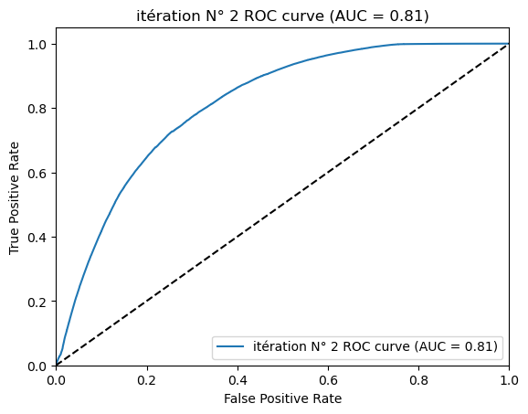

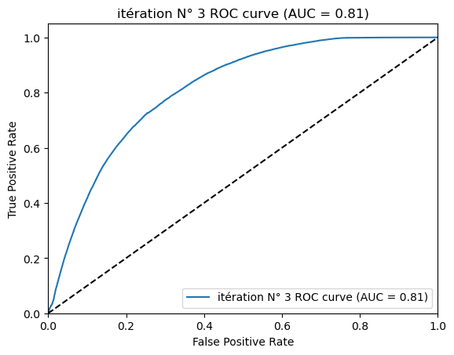

```python
# Entrainement du modèle
X = X_train
y = Y_train
it = 1
print_Html("###<font color='Orange'>**Méthode backward - itération N° "+ str(it)+ "**</font>")
model = sm.OLS(Y_train, X_train).fit()
# Afficher le tableau des coefficients
result = model
dfresult = summary_to_dataframe(model)
display(HTML(dfresult.to_html()))


# Boucle de sélection backward
while len(X_train.columns) > 1:
    # Calculer les valeurs p pour toutes les variables
    p_values = model.pvalues[0:]

    # Identifier la variable catégorielle avec la moyenne des p-values des modalités la plus élevée
    max_mean_pvalue = 0
    max_p_variable = None

    for col in X_train.columns:
        if '_' in col:
            var = col.split('_')[0]
            modalities = [c for c in X_train.columns if c.startswith(var)]
            modalities_pvalues = [p_values[m] for m in modalities if m in p_values.index]
            mean_pvalue = sum(modalities_pvalues) / len(modalities_pvalues)

            if mean_pvalue > max_mean_pvalue:
                if all(p > 0.05 for p in modalities_pvalues):
                        max_mean_pvalue = mean_pvalue
                        max_p_variable = var

    # Supprimer la variable catégorielle et les variables indicatrices associées
    if max_mean_pvalue > 0.05:
        related_variables = [col for col in X_train.columns if col.startswith(max_p_variable)]
        if (max_p_variable == 'Rec'):
                var1 = max_p_variable
                max_p_variable = 'Rec_Situation familiale'
                print_Html("###<font color='Bleu'>**La variable à supprimer est : "+ str(max_p_variable)+ "**</font>")
                max_p_variable = var1
        else:
                print_Html("###<font color='Bleu'>**La variable à supprimer est : "+ str(max_p_variable)+ "**</font>")

        print_Html("####<font color='Bleu'>**Sa moyenne des p-values est : " + str(max_mean_pvalue) + "**</font>")

        X_train = X_train.drop(related_variables, axis=1)

        it = it + 1
        print_Html("###<font color='Orange'>**Méthode backward - itération N° "+ str(it)+ "**</font>")
        model = sm.OLS(Y_train, X_train).fit()
        # Afficher le tableau des coefficients
        result = model
        dfresult = summary_to_dataframe(model)
        display(HTML(dfresult.to_html()))
############################################################################### DEBUT Affichage de la courbe ROC ##########################################
        # Calculer les scores de probabilité et les étiquettes prédites
        y_prob = model.predict(X_train)
        y_pred = (y_prob > 0.5).astype(int)
        model_best_save = model
        y_pred_train_save = y_pred
        # Calculer la courbe ROC
        fpr, tpr, _ = roc_curve(y, y_prob)
        roc_auc = auc(fpr, tpr)

        accuracy = accuracy_score(y, y_pred)
        accuracy_train_save = accuracy
        print_Html("###<font color='Orange'>**L'exactitude : "+ str(accuracy)+ "**</font>")

        # Tracer la courbe ROC
        plt.figure()
        plt.title('itération N° ' + str(it)+ ' ROC curve (AUC = %0.2f)' % roc_auc)
        plt.plot(fpr, tpr, label='itération N° ' + str(it)+ ' ROC curve (AUC = %0.2f)' % roc_auc)
        plt.plot([0, 1], [0, 1], 'k--')
        plt.xlim([0.0, 1.0])
        plt.ylim([0.0, 1.05])
        plt.xlabel('False Positive Rate')
        plt.ylabel('True Positive Rate')
        plt.legend(loc='lower right')  # Ajouter la légende avec l'AUC
############################################################################# FIN Affichage de la courbe ROC ##########################################
    else:
        break

print_Html("###<font color='Bleu'>**Le modèle est désormais optimal**</font>")
```

## **7. Tableau des coefficients**

```python
# Affichage du Tableau des coefficients
result_save_train = model_best_save
X_train_save = X_train
Y_train_save = Y_train
dfresult = summary_to_dataframe(model)
display(HTML(dfresult.to_html()))
```

|  | coef | Odds ratio | Interval de conf. min | Interval de conf. max | P-value |
| --- | --- | --- | --- | --- | --- |
| TrancheAge_1_Sans age | -0.028829 | 0.971583 | -0.032445 | -0.025214 | 0.0000 |
| TrancheAge_2_Moins de 40 ans | 0.001119 | 1.001120 | -0.003220 | 0.005458 | 0.6132 |
| TrancheAge_3_Entre 40 et 60 | -0.036419 | 0.964236 | -0.040358 | -0.032480 | 0.0000 |
| readhesion_readherent | 0.322587 | 1.380695 | 0.319400 | 0.325775 | 0.0000 |
| TrancheDureeAdhesion_1_Non adherent | 0.263168 | 1.301045 | 0.258221 | 0.268115 | 0.0000 |
| TrancheDureeAdhesion_2_moins de 18 mois | 0.276160 | 1.318059 | 0.272354 | 0.279965 | 0.0000 |
| TrancheDureeAdhesion_3_entre 18 et 46 mois | -0.000017 | 0.999983 | -0.003622 | 0.003587 | 0.9924 |
| domiciliation_Alsace-Est | -0.020607 | 0.979604 | -0.024224 | -0.016989 | 0.0000 |
| domiciliation_Centre-Paris | -0.009787 | 0.990261 | -0.013469 | -0.006104 | 0.0000 |
| domiciliation_Littoral | 0.001223 | 1.001224 | -0.001949 | 0.004395 | 0.4497 |
| r_score_2 | 0.026814 | 1.027177 | 0.022842 | 0.030786 | 0.0000 |
| r_score_3 | 0.162972 | 1.177003 | 0.159028 | 0.166916 | 0.0000 |
| r_score_4 | 0.294141 | 1.341974 | 0.289902 | 0.298381 | 0.0000 |
| f_score_1 | 0.154906 | 1.167548 | 0.148661 | 0.161151 | 0.0000 |
| f_score_2 | 0.074710 | 1.077572 | 0.068407 | 0.081013 | 0.0000 |
| f_score_3 | 0.012095 | 1.012168 | 0.007035 | 0.017154 | 0.0000 |
| m_score_1 | -0.018784 | 0.981392 | -0.027836 | -0.009731 | 0.0000 |
| m_score_2 | -0.021462 | 0.978766 | -0.029107 | -0.013817 | 0.0000 |
| m_score_3 | -0.040592 | 0.960221 | -0.046202 | -0.034981 | 0.0000 |
| TIC_TOTALTTC_CAT_Q1_inferieur_59 | -0.031961 | 0.968545 | -0.041382 | -0.022540 | 0.0000 |
| TIC_TOTALTTC_CAT_Q2_entre_59_108 | -0.018935 | 0.981243 | -0.026695 | -0.011175 | 0.0000 |
| TIC_TOTALTTC_CAT_Q3_entre_108_184 | -0.005384 | 0.994631 | -0.011418 | 0.000651 | 0.0804 |
| MONTANTREMISE_CAT_Q1_inferieur_0.5 | 0.042399 | 1.043311 | 0.037558 | 0.047241 | 0.0000 |
| MONTANTREMISE_CAT_Q2_entre_0.5_6 | 0.000166 | 1.000166 | -0.004251 | 0.004583 | 0.9413 |
| MONTANTREMISE_CAT_Q3_entre_6_12 | -0.000629 | 0.999371 | -0.004713 | 0.003455 | 0.7626 |
| TOTAL_CAT_Q1_inferieur_41 | 0.029868 | 1.030318 | 0.017458 | 0.042278 | 0.0000 |
| TOTAL_CAT_Q2_entre_41_77 | 0.031287 | 1.031781 | 0.020930 | 0.041644 | 0.0000 |
| TOTAL_CAT_Q3_entre_77_129 | 0.019210 | 1.019396 | 0.011234 | 0.027186 | 0.0000 |
| MARGESORTIE_CAT_Q1_inferieur_20 | 0.041031 | 1.041884 | 0.029027 | 0.053034 | 0.0000 |
| MARGESORTIE_CAT_Q2_entre_20_37 | 0.027995 | 1.028390 | 0.017975 | 0.038014 | 0.0000 |
| MARGESORTIE_CAT_Q3_entre_37_61 | 0.008306 | 1.008341 | 0.000589 | 0.016024 | 0.0349 |
| U1_CAT_Q1_moins de 4 | 0.013777 | 1.013872 | 0.012608 | 0.014946 | 0.0000 |
| U1_CAT_Q2_Entre 4 et 9 | -0.002720 | 0.997283 | -0.003855 | -0.001586 | 0.0000 |
| U1_CAT_Q3_Entre 10 et 18 | -0.003236 | 0.996770 | -0.005384 | -0.001087 | 0.0032 |
| U2_CAT_Q1_moins de 2 | 0.013777 | 1.013872 | 0.012608 | 0.014946 | 0.0000 |
| U2_CAT_Q2_Entre 2 et 3 | -0.002720 | 0.997283 | -0.003855 | -0.001586 | 0.0000 |
| U2_CAT_Q3_Entre 4 et 7 | -0.003236 | 0.996770 | -0.005384 | -0.001087 | 0.0032 |
| U3_CAT_Q1_moins de 5 | 0.011057 | 1.011118 | 0.009600 | 0.012513 | 0.0000 |
| U4_CAT_Q1_moins de 3 | 0.011057 | 1.011118 | 0.009600 | 0.012513 | 0.0000 |

## **6. Conclusion concernant la sélection des variables**

- **Le principe de parcimonie** voudrait que nous jouons le modèle avec le moins de variables possibles. On peut retirer une variable qualitative si aucune de ses modalités n’a un coefficient significatif, c'est à dire, que les P-values de toutes les modalités de la variable sont supérieurs au seuil d’erreur fixé (5%).

## **7. L'exactitude sur le jeux d'entrainement**

```python
print_Html("**L'exactitude sur le jeux de train est :**  <font color='yellow'>**" + " : {:.2f}".format(accuracy_train_save) + "**</font>")
```

**L'exactitude sur le jeux de train est :** **: 0.74**

## **8. Matrice de confusion jeux de train**

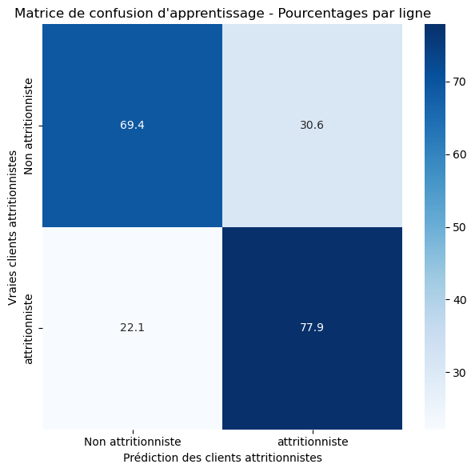

```python
# Obtenir les prédictions du modèle
y_pred = model.predict(X_train)

# Convertir les prédictions en classes binaires
y_pred_binary = (y_pred >= 0.5).astype(int)

# Créer une matrice de confusion
confusion_matrix = pd.crosstab(index=Y_train, columns=y_pred_binary, rownames=['Vraies étiquettes'], colnames=['Prédictions'])

# Calculer les pourcentages de chaque classe en divisant par les totaux des lignes ou des colonnes
row_percentages = confusion_matrix.div(confusion_matrix.sum(axis=1), axis=0) * 100
column_percentages = confusion_matrix.div(confusion_matrix.sum(axis=0), axis=1) * 100

# Définir les étiquettes personnalisées pour les classes
classes_labels = ['Non attritionniste', 'attritionniste']

# Afficher la matrice de confusion sous forme de graphique
plt.figure(figsize=(12, 6))

# Graphique pour les pourcentages par ligne
plt.subplot(1, 2, 1)
sns.heatmap(row_percentages, annot=True, fmt=".1f", cmap='Blues', xticklabels=classes_labels, yticklabels=classes_labels)
plt.xlabel('Prédiction des clients attritionnistes')
plt.ylabel('Vraies clients attritionnistes')
plt.title("Matrice de confusion d'apprentissage - Pourcentages par ligne")


plt.tight_layout()
plt.show()
```

## **9. Précision, Rappel et Score sur le jeu de train**

```python
# Calcul de l'exactitude, la précision, la sensibilité
print_Html("##<font color='bleu'>**L'exactitude, la précision, la sensibilité et le f1-score sur le jeux de train est :**</font>")
print(classification_report(pd.to_numeric(Y_train),y_pred_train_save))
```

**L'exactitude, la précision, la sensibilité et le f1-score sur le jeux de train est :**

```
              precision    recall  f1-score   support

           0       0.76      0.69      0.72    206069
           1       0.72      0.78      0.75    205882

    accuracy                           0.74    411951
   macro avg       0.74      0.74      0.74    411951
weighted avg       0.74      0.74      0.74    411951
```

## **10. Matrice de confusion jeux de test**

```python
#Creation du jeux de test X_test
X_test = X_test.loc[:, X_train.columns]
X_test_Save = X_test
```

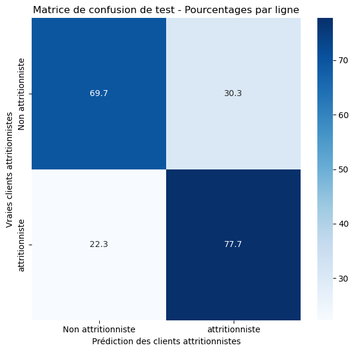

```python
# Obtenir les prédictions du modèle
y_pred = model.predict(X_test)

# Convertir les prédictions en classes binaires
y_pred_binary = (y_pred >= 0.5).astype(int)

# Créer une matrice de confusion
confusion_matrix = pd.crosstab(index=Y_test, columns=y_pred_binary, rownames=['Vraies étiquettes'], colnames=['Prédictions'])

# Calculer les pourcentages de chaque classe en divisant par les totaux des lignes ou des colonnes
row_percentages = confusion_matrix.div(confusion_matrix.sum(axis=1), axis=0) * 100
column_percentages = confusion_matrix.div(confusion_matrix.sum(axis=0), axis=1) * 100

# Définir les étiquettes personnalisées pour les classes
classes_labels = ['Non attritionniste', 'attritionniste']

# Afficher la matrice de confusion sous forme de graphique
plt.figure(figsize=(12, 6))

# Graphique pour les pourcentages par ligne
plt.subplot(1, 2, 1)
sns.heatmap(row_percentages, annot=True, fmt=".1f", cmap='Blues', xticklabels=classes_labels, yticklabels=classes_labels)
plt.xlabel('Prédiction des clients attritionnistes')
plt.ylabel('Vraies clients attritionnistes')
plt.title("Matrice de confusion de test - Pourcentages par ligne")

plt.tight_layout()
plt.show()
```

## **11. L'exactitude sur le jeux de test**

```python
# calcul de l'exactitude
y_prob_test = model_best_save.predict(X_test)
y_pred_test = (y_prob_test > 0.5).astype(int)
accuracy = accuracy_score(Y_test, y_pred_test)
print_Html("**L'exactitude sur le jeux de test est :**  <font color='yellow'>**" + " : {:.2f}".format(accuracy) + "**</font>")
```

**L'exactitude sur le jeux de test est :** **: 0.74**

## **12. Précision, Rappel et Score sur le jeu de test**

```python
# Calcul de la précision, la sensibilité et le f1-score sur le jeux de test est
print_Html("##<font color='bleu'>**L'exactitude, la précision, la sensibilité et le f1-score sur le jeux de test est :**</font>")
print(classification_report(pd.to_numeric(Y_test),y_pred_test))
```

**L'exactitude, la précision, la sensibilité et le f1-score sur le jeux de test est :**

```
              precision    recall  f1-score   support

           0       0.76      0.70      0.73     88182
           1       0.72      0.78      0.75     88369

    accuracy                           0.74    176551
   macro avg       0.74      0.74      0.74    176551
weighted avg       0.74      0.74      0.74    176551
```

## **13. Mesure de la performance du modèle - Informations techniques**

**L'exactitude** mesure la proportion de prédictions correctes (VP) par rapport à l'ensemble des prédictions. Sa valeur de **0.74 indique un taux élévé de vrais positifs**. Cependant, l'exactitude seule peut être trompeuse. Il est donc important de prendre en compte d'autres mesures pour une évaluation plus complète comme : la **précision**, le **rappel(recall)** et **F1-score**.

**La précision** mesure la proportion de vrais positifs (VP) parmi les observations prédites comme positives (VP + FP). Elle indique la capacité du modèle à identifier correctement les valeurs positives. Sa valeur élevée de 0.72 indique **un faible taux de faux positifs**.

**La sensibilité (Recall)** mesure la proportion de vrais positifs (VP) parmi les observations réellement positives (VP + FN). Il évalue la capacité du modèle à détecter les valeurs positives. **Sa valeur élevée de 0.78 indique un faible taux de faux négatifs.**.

**Le score F1 (F1-score)** est une mesure qui combine la précision (vrais positifs) et la sensibilité (faux négatifs) en une seule valeur. Il est utile lorsque on souhaite trouver un équilibre entre la précision et la sensibilité. Le score F1 est calculé à partir de la moyenne harmonique de la précision et la sensibilité, fournissant une mesure globale de la performance du modèle. **Sa valeur élevée de 0.75 confirme que notre modèle est performant.**

D'après **la courbe ROC**, l'AUC fournit une indication de la performance globale du modèle, indépendamment du seuil de classification choisi. **Sa valeur élevée de 0.81 indique une bonne capacité discriminante du modèle.**

**Au vu de toutes ces mesures, nous pouvons estimer que le modèle est globalement performant.**

## **14. Mesure de la robustesse du modèle - Informations techniques**

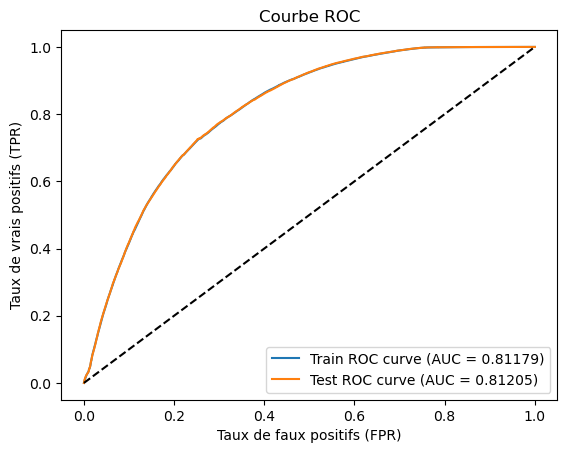

```python
# Calcul des courbes ROC des jeux de train et de test
y_train_pred = model.predict(X_train)
y_test_pred = model.predict(X_test)
# Calculer les taux de faux positifs (FPR) et de vrais positifs (TPR) pour le jeu de train
fpr_train, tpr_train, _ = roc_curve(Y_train, y_train_pred)
roc_auc_train = auc(fpr_train, tpr_train)

# Calculer les taux de faux positifs (FPR) et de vrais positifs (TPR) pour le jeu de test
fpr_test, tpr_test, _ = roc_curve(Y_test, y_test_pred)
roc_auc_test = auc(fpr_test, tpr_test)

# Tracer les courbes ROC
plt.plot(fpr_train, tpr_train, label='Train ROC curve (AUC = %0.5f)' % roc_auc_train)
plt.plot(fpr_test, tpr_test, label='Test ROC curve (AUC = %0.5f)' % roc_auc_test)
plt.plot([0, 1], [0, 1], 'k--')  # Ligne en pointillés pour le classificateur aléatoire
plt.xlabel('Taux de faux positifs (FPR)')
plt.ylabel('Taux de vrais positifs (TPR)')
plt.title('Courbe ROC')
plt.legend(loc='lower right')
plt.show()
```

Nous pouvons dire que le modèle est robuste parce que l'AUC obtenu sur l'échantillon test (**0.81205**) est très proche à de celui obtenu sur l'échantillon d'aprrentissage (**0.81179**).